# TD 11 - Arbres de décision

Théodore BOURGEON

Printemps 2019

# 1. Arbres de décision avec R

## 1.1 Fonctions

On commencera par se familiariser avec l’implémentation R de l’algorithme CART. On chargera tout d’abord les packages rpart et rpart.plot. On analysera les fonctions suivantes.

```r
#install.packages(rpart)
#install.packages("rpart.plot")
library(rpart)
library(rpart.plot)
```

- La fonction **rpart** permet de faire l’apprentissage d’un modèle d’arbre (pour construire l’arbre complet, on prendra soin de fixer `control=rpart.control(minsplit=1, cp=0))`.
- La fonction **prune** permet d’élaguer l’arbre ainsi obtenu, en choisissant une valeur du paramètre $\lambda$ de coût-complexité (argument cp).
- La fonction **predict** permet de classer un ensemble de données au moyen d’un arbre de décision préalablement appris.

On pourra utiliser la fonction **prp** (package rpart.plot) pour afficher un objet de type rpart, ainsi que la fonction **front.tree** fournie pour afficher les frontières de décision (dans le cas de données en dimension p = 2).

## 1.2 Questions

### 1.2.1 On considérera tout d’abord les données iris. Construire l’arbre complet permettant de prédire l’espèce à partir des variables explicatives Sepal.Length et Petal.Length, en utilisant toutes les données pour apprendre le modèle. Afficher l’arbre complet et les frontières de décision correspondantes.

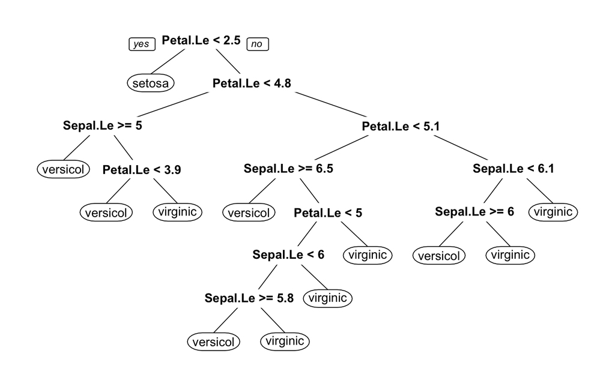

```r
attach(iris)
#Arbre complet + toute la séquence des arbres élagués
tree <- rpart(Species~Sepal.Length+Petal.Length, data = iris,control=rpart.control(minsplit=1, cp=0))
prp(tree)
```

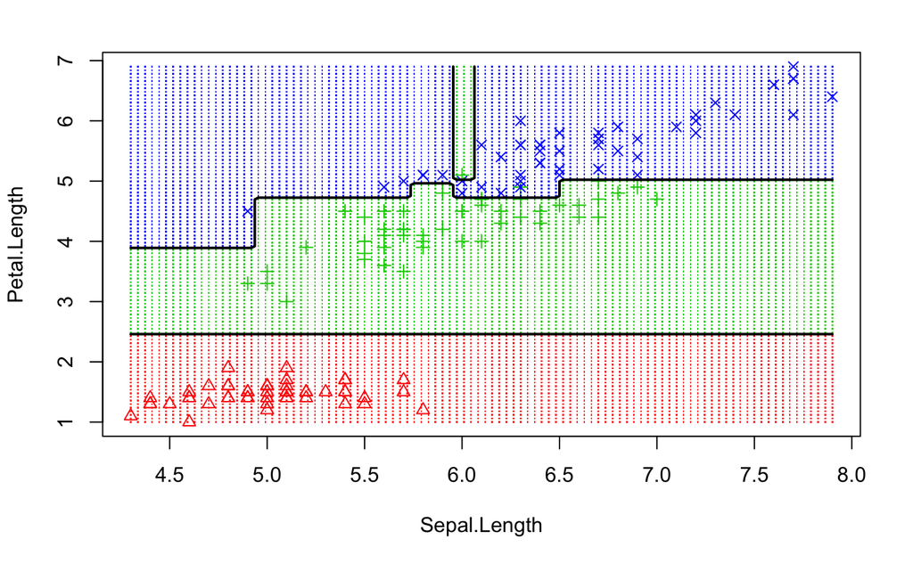

```r
# Affichage frontière
source("fonctions/front.tree.r")
front.tree(tree, iris[,c(1,3,5)], class = "Species")
```

### 1.2.2 Comment accéder à la séquence de sous-arbres emboîtés entre l’arbre complet et la racine ? Afficher les valeurs du paramètre $\lambda$ de coût-complexité et les informations correspondantes (taille de l’arbre, erreur, etc).

```r
#   cptable = a matrix of information on the optimal prunings based on a complexity parameter.
tree$cptable
```

```
           CP nsplit rel error xerror       xstd
1 0.500000000      0      1.00   1.21 0.04836666
2 0.430000000      1      0.50   0.65 0.06069047
3 0.015000000      2      0.07   0.09 0.02908608
4 0.005000000      4      0.04   0.10 0.03055050
5 0.003333333      8      0.02   0.09 0.02908608
6 0.000000000     11      0.01   0.09 0.02908608
```

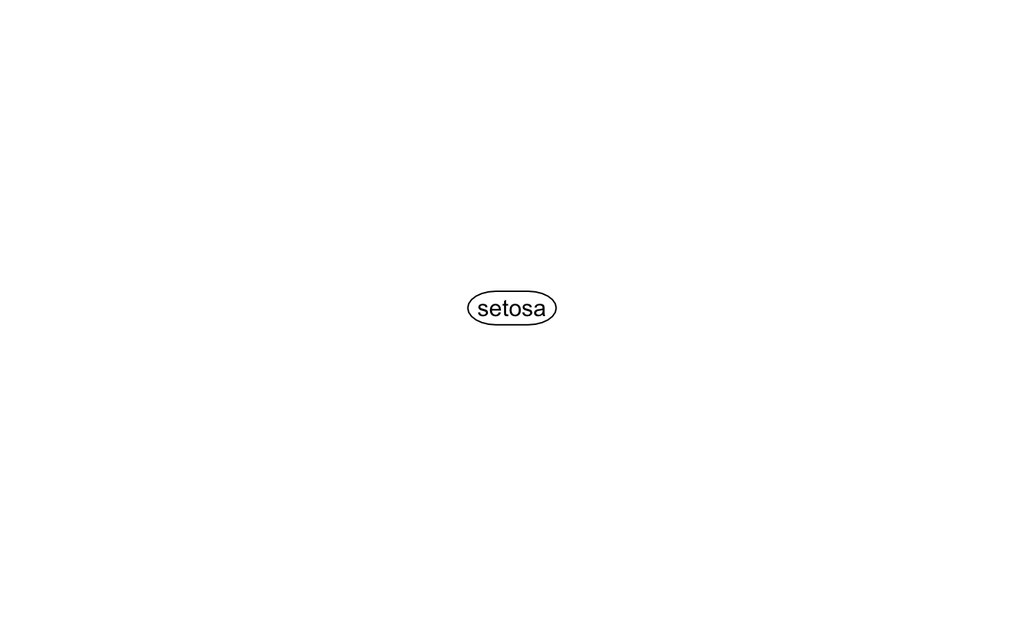

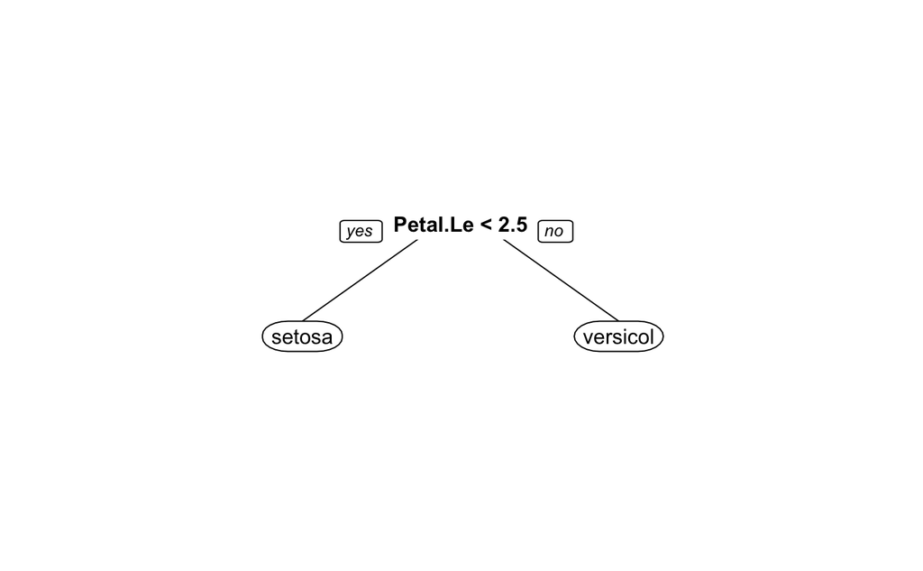

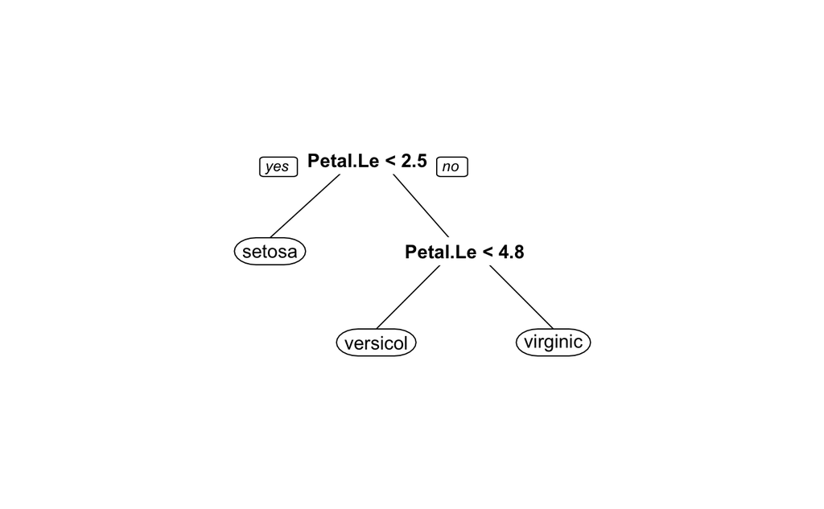

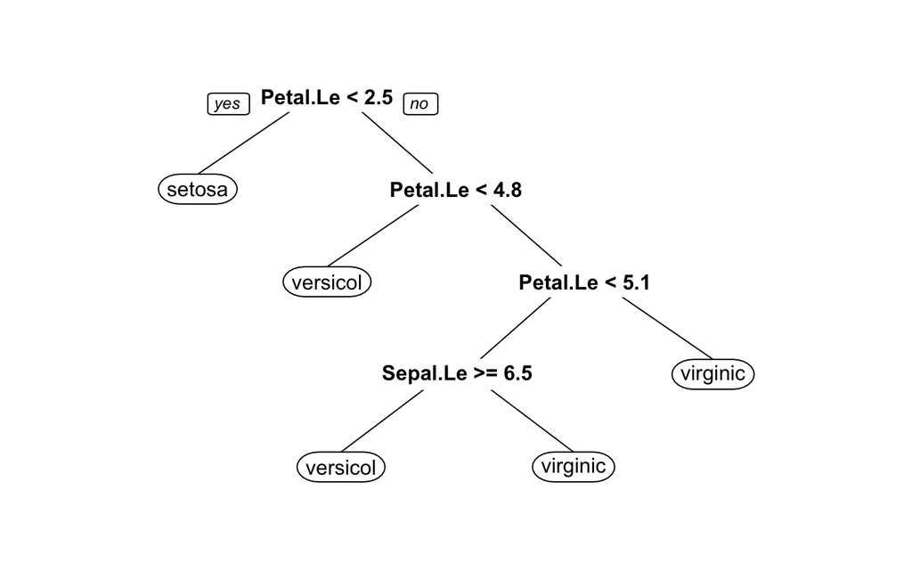

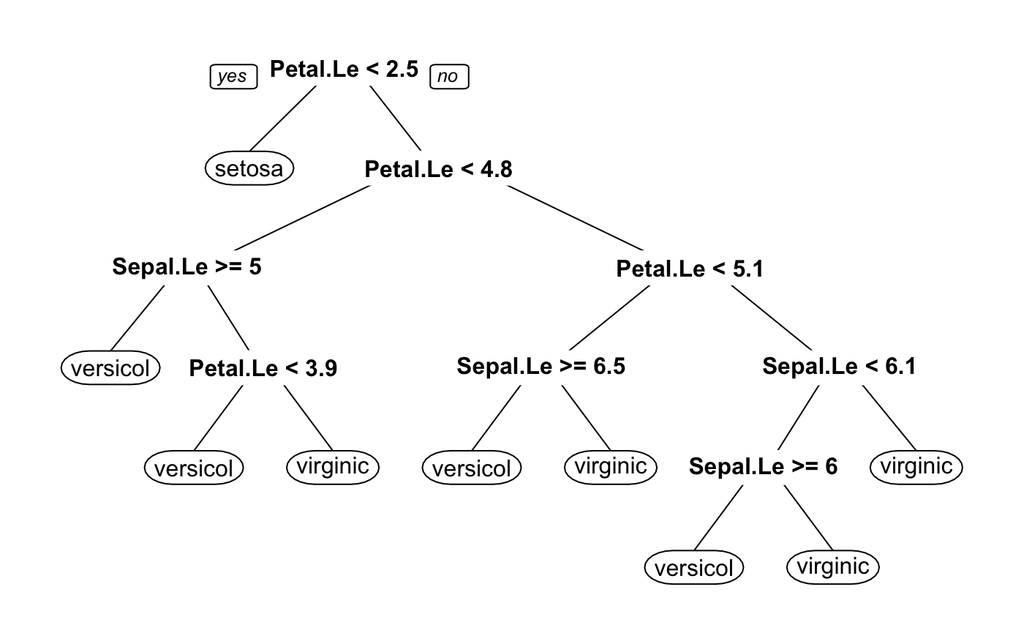

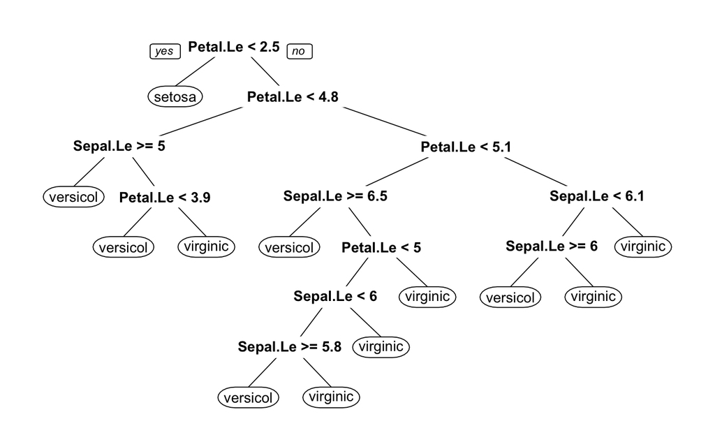

```r
for (i in tree$cptable[,1]) {
  tree.prune <-prune(tree,i)
  prp(tree.prune)
}
```

### 1.2.3 Déterminer le sous-arbre optimal, c’est-à-dire correspondant à l’erreur de validation la plus faible, et l’afficher.

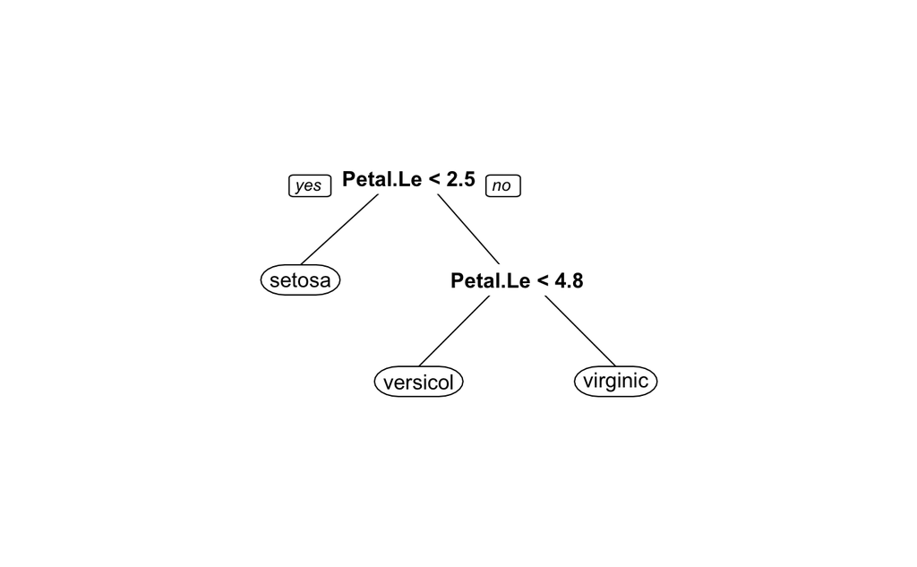

```r
#erreur min
optiCp <- tree$cptable[which.min(tree$cptable[,4]),1]
tree.opti <- prune(tree, optiCp)
prp(tree.opti)
```

# 2. Application

## 2.1 Test sur données simulées

- 1. séparer le jeu de données en un ensemble d’apprentissage et un ensemble de test ;
- 2. apprendre le modèle d’arbre sur l’ensemble d’apprentissage,
- 3. effectuer le classement des données de test et calculer le taux d’erreur associé.

```r
data1 <- read.csv("donnees/Synth1-1000.csv")
data2 <- read.csv("donnees/Synth2-1000.csv")
data3 <- read.csv("donnees/Synth3-1000.csv")
source("fonctions/separ1.R")
for (synth in list(data1, data2,data3) ) {
  ERR <- rep(0, 50)
  for (i in 1:50) {
    data.sep <- separ1(synth[,1:2], synth$z)
    data.sep$zapp <- as.factor(data.sep$zapp)
    datafull <- data.frame(cbind(data.sep$Xapp,data.sep$zapp))

    tree <- rpart(data.sep.zapp~V1+V2, data = datafull, control=rpart.control(minsplit=1, cp=0))
    optiCp <- tree$cptable[which.min(tree$cptable[,4]),1]
    tree.opti <- prune(tree, optiCp)
    pred <- predict(tree.opti, newdata = data.sep$Xtst, type = "class")
    err <- mean(pred != data.sep$ztst)
    ERR[i] <- err
  }
  print(mean(ERR))
}
```

```
[1] 0.04732733
[1] 0.07447447
[1] 0.1030631
```

## 2.2 Test sur données réelles

### 2.2.1 Données Pima

On souhaite appliquer les arbres de décision à deux jeux de données déjà considérés précédemment :

- la prédiction du diabète chez les individus d’une population d’amérindiens (données Pima) :

```r
Pima <- read.csv("donnees/Pima.csv", header=T)
Pima.X <- Pima[,-8]
Pima.z <- as.factor(Pima[,8])
#la détection de spams (données spambase puis spambase2) :
Spam <- read.csv("donnees/spambase.csv", header=T, row.names=1)
Spam.X <- Spam[,-58]
Spam.z <- as.factor(Spam[,58])
source("fonctions/separ1.R")
ERR <- rep(0, 50)
for (i in 1:50) {
  data.sep <- separ1(Pima.X, Pima.z)
  data.sep$zapp <- as.factor(data.sep$zapp)
  datafull <- data.frame(cbind(data.sep$Xapp,data.sep$zapp))

  tree <- rpart(data.sep.zapp~., data = datafull, control=rpart.control(minsplit=1, cp=0))
  optiCp <- tree$cptable[which.min(tree$cptable[,4]),1]
  tree.opti <- prune(tree, optiCp)
  pred <- predict(tree.opti, newdata = data.sep$Xtst, type = "class")
  err <- mean(pred != data.sep$ztst)
  ERR[i] <- err
}
mean(ERR)
```

```
[1] 0.2424859
```

```r
ERR <- rep(0, 50)
for (i in 1:50) {
  data.sep <- separ1(Spam.X, Spam.z)
  data.sep$zapp <- as.factor(data.sep$zapp)
  datafull <- data.frame(cbind(data.sep$Xapp,data.sep$zapp))

  tree <- rpart(data.sep.zapp~., data = datafull, control=rpart.control(minsplit=1, cp=0))
  optiCp <- tree$cptable[which.min(tree$cptable[,4]),1]
  tree.opti <- prune(tree, optiCp)
  pred <- predict(tree.opti, newdata = data.sep$Xtst, type = "class")
  err <- mean(pred != data.sep$ztst)
  ERR[i] <- err
}
mean(ERR)
```

```
[1] 0.0821382
```

Pour chacun de ces jeux de données, on répétera la procédure de séparation des données, apprentissage, classement et calcul du taux d’erreur. On comparera les résultats obtenus à ceux obtenus avec les méthodes étudiées précédemment (analyse discriminante, régression logistique).